# intubate <||> 1.0.0

Roberto Bertolusso

August 27, 2016

##### License: GPL >= 2

The aim of `intubate` (logo `<||>`) is to offer a painless way to add R functions that are not pipe-aware to data science pipelines implemented by `magrittr` with the operator `%>%`, without having to rely on workarounds of varying complexity. It also implements three extensions called `intubOrders`, `intuEnv`, and `intuBags`.

#### Installation

- the latest released version from CRAN (1.0.0) with

```r
install.packages("intubate")
```

- the latest development version from github with

```r
# install.packages("devtools")
devtools::install_github("rbertolusso/intubate")
```

## In a nutshell

If you like `magrittr` pipelines (%>%) and you are looking for an alternative to performing a statistical analysis in the following way:

```r
fit <- lm(sr ~ pop15, LifeCycleSavings)
summary(fit)
```

```
##
## Call:
## lm(formula = sr ~ pop15, data = LifeCycleSavings)
##
## Residuals:
##    Min     1Q Median     3Q    Max
## -8.637 -2.374  0.349  2.022 11.155
##
## Coefficients:
##             Estimate Std. Error t value Pr(>|t|)
## (Intercept) 17.49660    2.27972   7.675 6.85e-10 ***
## pop15       -0.22302    0.06291  -3.545 0.000887 ***
## ---
## Signif. codes:  0 '***' 0.001 '**' 0.01 '*' 0.05 '.' 0.1 ' ' 1
##
## Residual standard error: 4.03 on 48 degrees of freedom
## Multiple R-squared:  0.2075, Adjusted R-squared:  0.191
## F-statistic: 12.57 on 1 and 48 DF,  p-value: 0.0008866
```

`intubate` let’s you do it in these other ways:

```r
library(intubate)
library(magrittr)
```

#### 1) Using interface (provided by intubate *or* user defined)

`ntbt_lm` is the interface provided to `lm`, and one of the over 450 interfaces `intubate` currently implements (for the list of 88 packages currently containing interfaces see below).

```r
LifeCycleSavings %>%
  ntbt_lm(sr ~ pop15) %>%    ## ntbt_lm is the interface to lm provided by intubate
  summary()
```

```
##
## Call:
## lm(formula = sr ~ pop15)
##
## Residuals:
##    Min     1Q Median     3Q    Max
## -8.637 -2.374  0.349  2.022 11.155
##
## Coefficients:
##             Estimate Std. Error t value Pr(>|t|)
## (Intercept) 17.49660    2.27972   7.675 6.85e-10 ***
## pop15       -0.22302    0.06291  -3.545 0.000887 ***
## ---
## Signif. codes:  0 '***' 0.001 '**' 0.01 '*' 0.05 '.' 0.1 ' ' 1
##
## Residual standard error: 4.03 on 48 degrees of freedom
## Multiple R-squared:  0.2075, Adjusted R-squared:  0.191
## F-statistic: 12.57 on 1 and 48 DF,  p-value: 0.0008866
```

#### 2) Calling the non-pipe-aware function directly with `ntbt`

You do not *need* to use interfaces. You can call non-pipe-aware functions directly using `ntbt` (even those that currently do not have an interface provided by `intubate`).

```r
LifeCycleSavings %>%
  ntbt(lm, sr ~ pop15) %>%   ## ntbt calls lm without needing to use an interface
  summary()
```

```
##
## Call:
## lm(formula = sr ~ pop15)
##
## Residuals:
##    Min     1Q Median     3Q    Max
## -8.637 -2.374  0.349  2.022 11.155
##
## Coefficients:
##             Estimate Std. Error t value Pr(>|t|)
## (Intercept) 17.49660    2.27972   7.675 6.85e-10 ***
## pop15       -0.22302    0.06291  -3.545 0.000887 ***
## ---
## Signif. codes:  0 '***' 0.001 '**' 0.01 '*' 0.05 '.' 0.1 ' ' 1
##
## Residual standard error: 4.03 on 48 degrees of freedom
## Multiple R-squared:  0.2075, Adjusted R-squared:  0.191
## F-statistic: 12.57 on 1 and 48 DF,  p-value: 0.0008866
```

The help for each interface contains examples of use.

## Interfaces “on demand”

`intubate` allows you to create **your own** interfaces “on demand”, **right now**, giving you full power of decision regarding which functions to interface.

The ability to amplify the scope of `intubate` may prove to be particularly welcome if you are related to a particular field that may, in the long run, continue to lack interfaces due to my unforgivable, but unavoidable, ignorance.

As an example of creating an interface “on demand”, suppose the interface to `cor.test` was lacking in the current version of `intubate` and *suppose* (at least for a moment) that you want to create yours because you are searching for a pipeline-aware alternative to any of the following styles of coding (results not shown):

```r
data(USJudgeRatings)

## 1)
cor.test(USJudgeRatings$CONT, USJudgeRatings$INTG)

## 2)
attach(USJudgeRatings)
cor.test(CONT, INTG)
detach()

## 3)
with(USJudgeRatings, cor.test(CONT, INTG))

## 4)
USJudgeRatings %>%
   with(cor.test(CONT, INTG))
```

To be able to create an interface to `cor.test` “on demand”, the *only* thing you need to do is to add the following line of code somewhere before its use in your pipeline:

```r
ntbt_cor.test <- intubate          ## intubate is the helper function
```

Please note the **lack of parentheses**.

Nothing else is required.

The *only* thing you need to remember is that the names of an interface **must start** with `ntbt_` followed by the name of the *interfaced* function (`cor.test` in this particular case), no matter which function you want to interface.

Now you can use your “just baked” interface in any pipeline. A pipeline alternative to the above code may look like this:

```r
USJudgeRatings %>%
  ntbt_cor.test(CONT, INTG)           ## Use it right away
```

```
##
##  Pearson's product-moment correlation
##
## data:  CONT and INTG
## t = -0.8605, df = 41, p-value = 0.3945
## alternative hypothesis: true correlation is not equal to 0
## 95 percent confidence interval:
##  -0.4168591  0.1741182
## sample estimates:
##        cor
## -0.1331909
```

### Calling non-pipe-aware functions directly with `ntbt`

Of course, as already stated, you **do not have to create an interface** if you do not want to. You can **call the non-pipe-aware function directly** with `ntbt`, in the following way:

```r
USJudgeRatings %>%
  ntbt(cor.test, CONT, INTG)
```

```
##
##  Pearson's product-moment correlation
##
## data:  CONT and INTG
## t = -0.8605, df = 41, p-value = 0.3945
## alternative hypothesis: true correlation is not equal to 0
## 95 percent confidence interval:
##  -0.4168591  0.1741182
## sample estimates:
##        cor
## -0.1331909
```

You can potentially use `ntbt` with *any function*, also the ones without an interface provided by `intubate`. In principle, the functions you would like to call are the ones you cannot use directly in a pipeline (because `data` is not in first place in the definition of the function).

### Example showing different techniques

The link below is to Dr. Sheather’s website where code was extracted. In the link there is also information about the book. This code could be used to produce the plots in Figure 3.1 on page 46. Different strategies are illustrated.

http://www.stat.tamu.edu/~sheather/book/

#### 1) As in the book (without using pipes and attaching data):

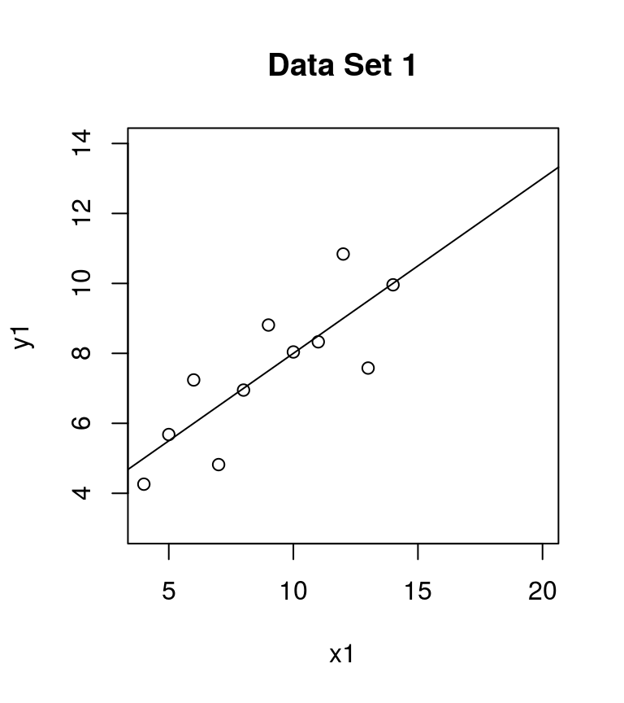

```r
attach(anscombe)
plot(x1, y1, xlim = c(4, 20), ylim = c(3, 14), main = "Data Set 1")
abline(lsfit(x1, y1))
```

```r
detach()
```

You needed to `attach` so variables are visible locally. If not, you should have used `anscombe$x1` and `anscombe$y1`. You could also have used `with`. Spaces were added for clarity and better comparison with code below.

#### 2) Using magrittr pipes (`%>%`) and `intubate` (1: provided interface and 2: `ntbt`):

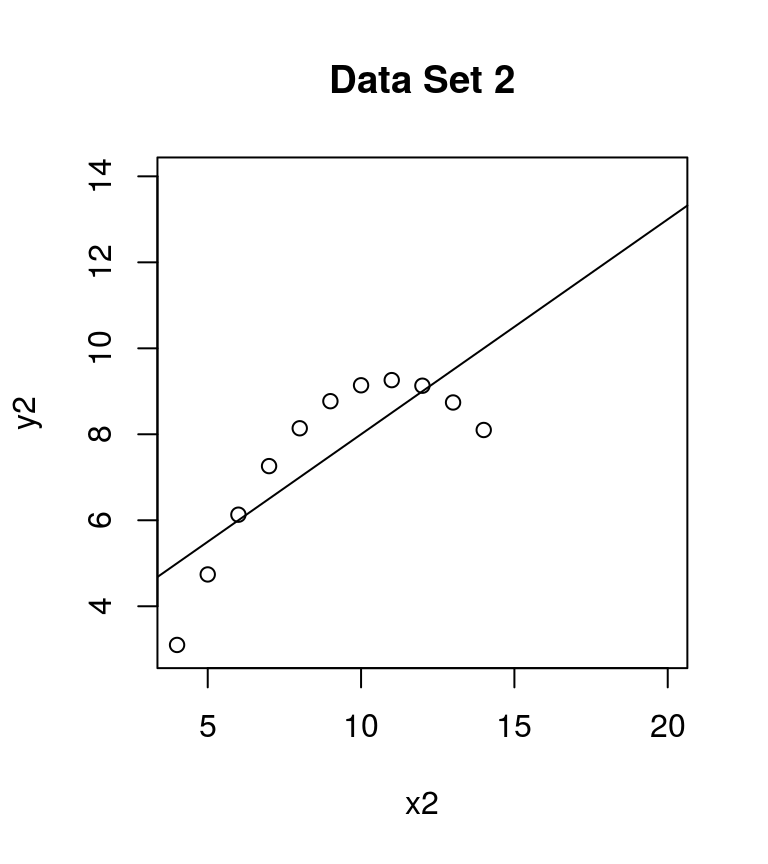

```r
anscombe %>%
  ntbt_plot(x2, y2, xlim = c(4, 20), ylim = c(3, 14), main = "Data Set 2") %>%
  ntbt(lsfit, x2, y2) %>%   # Call non-pipe-aware function directly with `ntbt`
  abline()                  # No need to interface 'abline'.
```

- `ntbt_plot` is the interface to `plot` provided by `intubate`. As `plot` returns `NULL`, `intubate` forwards (invisibly) its input automatically without having to use `%T>%`, so `lsfit` gets the original data (what it needs) and everything is done in one pipeline.
- `ntbt` let’s you call the non-pipe-aware function `lsfit` directly. You can use `ntbt` *always* (you do not need to use `ntbt_` interfaces if you do not want to), but `ntbt` is particularly useful to interface directly a non-pipe-aware function for which `intubate` does not provide an interface (as currently happens with `lsfit`).

#### 3) Defining interface “on demand”

If `intubate` does not provide an interface to a given function and you prefer to use interfaces instead of `ntbt`, you can create your own interface “on demand” and use it right away in your pipeline. To create an interface, it suffices the following line of code before its use:

```r
ntbt_lsfit <- intubate      # NOTE: we are *not* including parentheses.
```

That’s it, you have created you interface. Just remember that:

1. `intubate` interfaces **must** start with `ntbt_` followed by the name of the function to interface (`lsfit` in this case).
2. Parentheses are *not* used in the definition of the interface.

You can now use `ntbt_lsfit` in your pipeline as any other interfaced function:

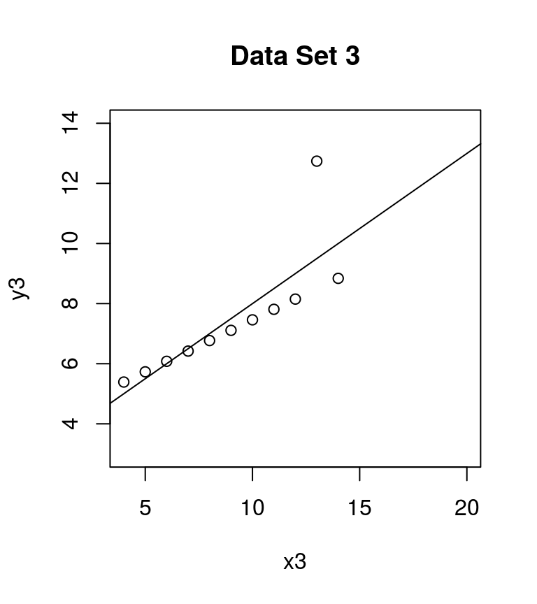

```r
anscombe %>%
  ntbt_plot(x3, y3, xlim = c(4, 20), ylim = c(3, 14), main = "Data Set 3") %>%
  ntbt_lsfit(x3, y3) %>%    # Using just created "on demand" interface
  abline()
```

#### 4) Using the formula variants:

Instead of the `X` `Y` approach, you can also use the formula variant. In this case, we will have to used `lm` as `lsfit` does not implement formulas.

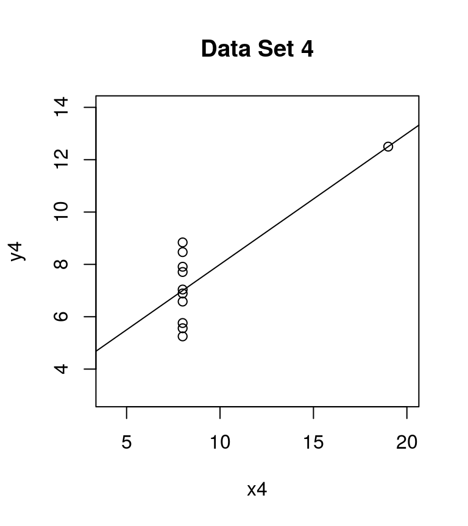

```r
anscombe %>%
  ntbt_plot(y4 ~ x4, xlim = c(4, 20), ylim = c(3, 14), main = "Data Set 4") %>%
  ntbt_lm(y4 ~ x4) %>%      # We use 'ntbt_lm' instead of 'ntbt_lmfit'
  abline()
```

## Extensions for pipelines provided by `intubate`

`intubate` implements three extensions:

- `intubOrders`,
- `intuEnv`, and
- `intuBags`.

These experimental features are functional for you to use. Unless you do not mind having to potentially make some changes to your code while the architecture solidifies, they are *not recommended* (yet) for production code.

## `intubOrders`

`intubOrders` allow, among other things, to:

- run, in place, functions on the input (`data`) to the interfaced function, such as `head`, `tail`, `dim`, `str`, `View`, …
- run, in place, functions that use the result generated by the interfaced function, such as `print`, `summary`, `anova`, `plot`, …
- forward the input to the interfaced function without using %T>%
- signal other modifications to the behavior of the interface

`intubOrders` are implemented by an `intuBorder` `<||>` (from where the logo of `intubate` originates).

The `intuBorder` contains 5 zones (`intuZones`?, maybe too much…):

`zone 1` **<** `zone 2` **|** `zone 3` **|** `zone 4` **>** `zone 5`

- `zone 1` and `zone 5` will be explained later
- `zone 2` is used to indicate the functions that are to be applied to the **input** to the interfaced function
- `zone 3` to modify the behavior of the interface
- `zone 4` to indicate the functions that are to be applied to the **result** of the interfaced function

For example, instead of running the following sequence of function calls (only plot shown):

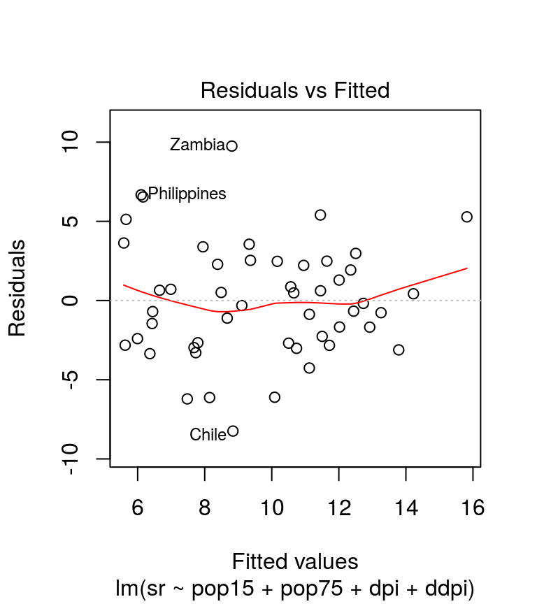

```r
head(LifeCycleSavings)
tail(LifeCycleSavings, n = 3)
dim(LifeCycleSavings)
str(LifeCycleSavings)
summary(LifeCycleSavings)
result <- lm(sr ~ pop15 + pop75 + dpi + ddpi, LifeCycleSavings)
print(result)
summary(result)
anova(result)
plot(result, which = 1)
```

you could have run, using an `intubOrder`:

```
##
## ntbt_lm(data = ., sr ~ pop15 + pop75 + dpi + ddpi)
##
## * head <||> input *
##              sr pop15 pop75     dpi ddpi
## Australia 11.43 29.35  2.87 2329.68 2.87
## Austria   12.07 23.32  4.41 1507.99 3.93
## Belgium   13.17 23.80  4.43 2108.47 3.82
## Bolivia    5.75 41.89  1.67  189.13 0.22
## Brazil    12.88 42.19  0.83  728.47 4.56
## Canada     8.79 31.72  2.85 2982.88 2.43
##
## * tail(#, n = 3) <||> input *
##            sr pop15 pop75    dpi  ddpi
## Uruguay  9.24 28.13  2.72 766.54  1.88
## Libya    8.89 43.69  2.07 123.58 16.71
## Malaysia 4.71 47.20  0.66 242.69  5.08
##
## * dim <||> input *
## [1] 50  5
##
## * str <||> input *
## 'data.frame':    50 obs. of  5 variables:
##  $ sr   : num  11.43 12.07 13.17 5.75 12.88 ...
##  $ pop15: num  29.4 23.3 23.8 41.9 42.2 ...
##  $ pop75: num  2.87 4.41 4.43 1.67 0.83 2.85 1.34 0.67 1.06 1.14 ...
##  $ dpi  : num  2330 1508 2108 189 728 ...
##  $ ddpi : num  2.87 3.93 3.82 0.22 4.56 2.43 2.67 6.51 3.08 2.8 ...
##
## * summary <||> input *
##        sr             pop15           pop75            dpi
##  Min.   : 0.600   Min.   :21.44   Min.   :0.560   Min.   :  88.94
##  1st Qu.: 6.970   1st Qu.:26.21   1st Qu.:1.125   1st Qu.: 288.21
##  Median :10.510   Median :32.58   Median :2.175   Median : 695.66
##  Mean   : 9.671   Mean   :35.09   Mean   :2.293   Mean   :1106.76
##  3rd Qu.:12.617   3rd Qu.:44.06   3rd Qu.:3.325   3rd Qu.:1795.62
##  Max.   :21.100   Max.   :47.64   Max.   :4.700   Max.   :4001.89
##       ddpi
##  Min.   : 0.220
##  1st Qu.: 2.002
```

[output cut: 36 more lines]

```
## F-statistic: 5.756 on 4 and 45 DF,  p-value: 0.0007904
##
##
## * anova <||> result *
## Analysis of Variance Table
##
## Response: sr
##           Df Sum Sq Mean Sq F value    Pr(>F)
## pop15      1 204.12 204.118 14.1157 0.0004922 ***
## pop75      1  53.34  53.343  3.6889 0.0611255 .
## dpi        1  12.40  12.401  0.8576 0.3593551
## ddpi       1  63.05  63.054  4.3605 0.0424711 *
## Residuals 45 650.71  14.460
## ---
## Signif. codes:  0 '***' 0.001 '**' 0.01 '*' 0.05 '.' 0.1 ' ' 1
```

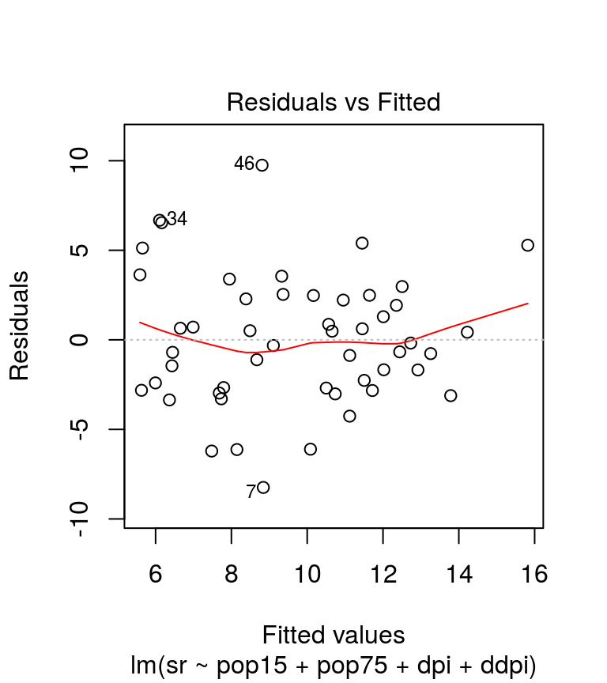

```r
LifeCycleSavings %>%
  ntbt_lm(sr ~ pop15 + pop75 + dpi + ddpi,
          "< head; tail(#, n = 3); dim; str; summary
             |i|
             print; summary; anova; plot(#, which = 1) >")
```

- Note:
  - `i` is used to force an invisible result
  - `#` is used as a placeholder either for the input or result in cases the call requires extra parameters.
- `intubOrders` may prove to be of interest to non-pipeline oriented people too (results not shown):

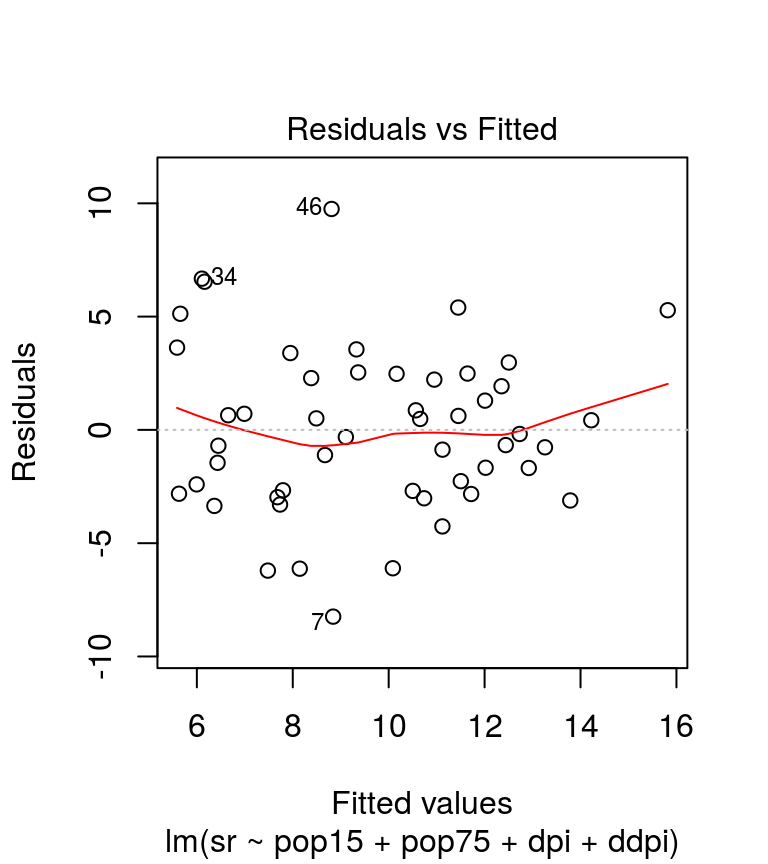

```r
ntbt_lm(LifeCycleSavings, sr ~ pop15 + pop75 + dpi + ddpi,
        "< head; tail(#, n = 3); dim; str; summary
           |i|
           print; summary; anova; plot(#, which = 1) >")
```

### `intubOrders` with collections of inputs

When using pipelines, the receiving function has to deal with the *whole* object that receives as its input. Then, it produces a result that, again, needs to be consumed as a whole by the following function.

`intubOrders` allow you to work with a collection of objects of any kind in *one* pipeline, selecting at each step which input to use.

As an example suppose you want to perform the following statistical procedures in one pipeline (results not shown).

```r
CO2 %>%
  ntbt_lm(conc ~ uptake)

USJudgeRatings %>%
  ntbt_cor.test(CONT, INTG)

sleep %>%
  ntbt_t.test(extra ~ group)
```

We will first create a collection (a `list` in this case, but it could also be `intuEnv` or an `intuBag`, explained later) containing the three dataframes:

```r
coll <- list(CO3 = CO2,
             USJudgeRatings1 = USJudgeRatings,
             sleep1 = sleep)
names(coll)
```

```
## [1] "CO3"             "USJudgeRatings1" "sleep1"
```

(We have changed the names to show we are not cheating…)

- Note: the objects of the collection *must* be named.

We will now use as source the *whole collection*.

The `intubOrder` will need the following info:

- `zone 1`, in each case, indicates which is the data.frame (or any other object) that we want to use as input in this particular function
- `zone 3` needs to include `f` to *forward* the input (if you want the next function to receive the whole collection, and not the result if this step)
- `zone 4` (optional) may contain a `print` (or `summary`) if you want something to be displayed

```r
coll %>%
  ntbt_lm(conc ~ uptake, "CO3 <|f| print >") %>%
  ntbt_cor.test(CONT, INTG, "USJudgeRatings1 <|f| print >") %>%
  ntbt_t.test(extra ~ group, "sleep1 <|f| print >") %>%
  names()
```

```
##
## ntbt_lm(data = ., conc ~ uptake)
##
## * print <||> result *
##
## Call:
## lm(formula = conc ~ uptake)
##
## Coefficients:
## (Intercept)       uptake
##       73.71        13.28
##
##
## ntbt_cor.test(data = ., CONT, INTG)
##
## * print <||> result *
##
##  Pearson's product-moment correlation
##
## data:  CONT and INTG
## t = -0.8605, df = 41, p-value = 0.3945
## alternative hypothesis: true correlation is not equal to 0
## 95 percent confidence interval:
##  -0.4168591  0.1741182
## sample estimates:
##        cor
## -0.1331909
##
##
## ntbt_t.test(data = ., extra ~ group)
##
## * print <||> result *
##
##  Welch Two Sample t-test
##
## data:  extra by group
## t = -1.8608, df = 17.776, p-value = 0.07939
## alternative hypothesis: true difference in means is not equal to 0
## 95 percent confidence interval:
##  -3.3654832  0.2054832
## sample estimates:
## mean in group 1 mean in group 2
##            0.75            2.33
```

```
## [1] "CO3"             "USJudgeRatings1" "sleep1"
```

- Note: `names()` was added at the end to show that we have forwarded the original collection to the end of the pipeline.

What happens if you would like to **save** the results of the function calls (or intermediate results of data manipulations)?

## `intuEnv` and `intuBags`

`intuEnv` and `intuBags` allow to save intermediate results without leaving the pipeline. They can also be used to contain the collections of objects.

Let us first consider

## `intuEnv`

When `intubate` is loaded, it creates `intuEnv`, an empty environment that can be populated with results that you want to use later.

You can access the `intuEnv` as follows:

```r
intuEnv()  ## intuEnv() returns invisible, so nothing is output
```

You can verify that, initially, it is empty:

```r
ls(intuEnv())
```

```
## character(0)
```

How can `intuEnv` be used?

Suppose that we want, instead of displaying the results of interfaced functions, save the objects returned by them. One strategy (the other is using `intuBags`) is to save the results to `intuEnv`.

#### How to save to `intuEnv`?

The `intubOrder` will need the following info:

- `zone 3` needs to include `f` to *forward* the input (if you want the next function to receive the whole collection, and not its result)
- `zone 5`, in each case, indicates the name that the result will have in the `intuEnv`

```r
coll %>%
  ntbt_lm(conc ~ uptake, "CO3 <|f|> lmfit") %>%
  ntbt_cor.test(CONT, INTG, "USJudgeRatings1 <|f|> ctres") %>%
  ntbt_t.test(extra ~ group, "sleep1 <|f|> ttres") %>%
  names()
```

```
## [1] "CO3"             "USJudgeRatings1" "sleep1"
```

As you can see, the collection stays unchanged, but look inside `intuEnv`

```r
ls(intuEnv())
```

```
## [1] "ctres" "lmfit" "ttres"
```

`intuEnv` has collected the results, that are ready for use.

Four strategies of using one of the collected results are shown below (output not shown):

#### Strategy 1

```r
intuEnv()$lmfit %>%
  summary()
```

#### Strategy 2

```r
attach(intuEnv())
lmfit %>%
  summary()
detach()
```

#### Strategy 3

```r
intuEnv() %>%
  ntbt(summary, "lmfit <||>")
```

#### Strategy 4

```r
intuEnv() %>%
  ntbt(I, "lmfit <|i| summary >")
```

`clear_intuEnv` can be used to empty the contents of `intuEnv`.

```r
clear_intuEnv()

ls(intuEnv())
```

```
## character(0)
```

### Associating `intuEnv` with the Global Environment

If you want your results to be saved to the Global environment (it could be *any* environment), you can associate `intuEnv` to it, so you can have your results available as any other saved object.

First let’s display the contents of the Global environment:

```r
ls()
```

```
## [1] "USJudgeRatings" "coll"           "fit"            "ntbt_cor.test"
## [5] "ntbt_lsfit"     "result"
```

`set_intuEnv` let’s you associate `intuEnv` to an environment. It takes an environment as parameter, and returns the current `intuEnv`, in case you want to save it to reinstate it later. If not, I think it will be just garbage collected (I may be wrong).

Let’s associate `intuEnv` to the global environment (saving the current `intuEnv`):

```r
saved_intuEnv <- set_intuEnv(globalenv())
```

Now, we re-run the pipeline:

```r
coll %>%
  ntbt_lm(conc ~ uptake, "CO3 <|f|> lmfit") %>%
  ntbt_cor.test(CONT, INTG, "USJudgeRatings1 <|f|> ctres") %>%
  ntbt_t.test(extra ~ group, "sleep1 <|f|> ttres") %>%
  names()
```

```
## [1] "CO3"             "USJudgeRatings1" "sleep1"
```

Before forgetting, let’s reinstate the original `intuEnv`:

```r
set_intuEnv(saved_intuEnv)
```

```
## <environment: R_GlobalEnv>
```

And now, let’s see if the results were saved to the global environment:

```r
ls()
```

```
##  [1] "USJudgeRatings" "coll"           "ctres"          "fit"
##  [5] "lmfit"          "ntbt_cor.test"  "ntbt_lsfit"     "result"
##  [9] "saved_intuEnv"  "ttres"
```

They were.

Now the results are at your disposal to use as any other variable (result not shown):

```r
lmfit %>%
  summary()
```

### Using `intuEnv` as source of the pipeline

You can use `intuEnv` (or any other environment) as the input of your pipeline.

We already cleared the contents of `intuEnv`, but let’s do it again to get used to how to do it:

```r
clear_intuEnv()

ls(intuEnv())
```

```
## character(0)
```

Let’s populate `intuEnv` with the same objects as before:

```r
intuEnv(CO3 = CO2,
        USJudgeRatings1 = USJudgeRatings,
        sleep1 = sleep)

ls(intuEnv())
```

```
## [1] "CO3"             "USJudgeRatings1" "sleep1"
```

When using an environment, such as `intuEnv`, as the source of your pipeline, there is no need to specify `f` in `zone 3`, as the environment is always forwarded (the same happens when the source is an `intuBag`).

Keep in mind that, if you are saving results and your source is an environment other than `intuEnv`, the results will be saved to `intuEnv`, and not to the source enviromnent. If the source is an `intuBag`, the results will be saved to the `intuBag`, and not to `intuEnv`.

We will run the same pipeline as before, but this time we will add `subset` and `summary`(called directly with `ntbt`) to illustrate how we can use a previously generated result (such as from data transformations) in the *same* pipeline in which it was generated. We will use `intuEnv` as the source of the pipeline.

```r
intuEnv() %>%
  ntbt(subset, Treatment == "nonchilled", "CO3 <||> CO3nc") %>%
  ntbt_lm(conc ~ uptake, "CO3nc <||> lmfit") %>%
  ntbt_cor.test(CONT, INTG, "USJudgeRatings1 <||> ctres") %>%
  ntbt_t.test(extra ~ group, "sleep1 <||> ttres") %>%
  ntbt(summary, "lmfit <||> lmsfit") %>%
  names()
```

```
## [1] "USJudgeRatings1" "ttres"           "CO3nc"           "ctres"
## [5] "lmsfit"          "lmfit"           "sleep1"          "CO3"
```

- Note that, as `subset` is already pipe-aware (`data` is its first parameter), you have two ways of proceeding. One is the one illustrated above (same strategy used on non-pipe-aware functions). The other, that works *only* when using pipe-aware functions, is:

```r
intuEnv() %>%
  ntbt(subset, CO3, Treatment == "nonchilled", "<||> CO3nc")
```

## `intuBags`

`intuBags` differ from `intEnv` in that they are based on lists, instead than on environments. Even if (with a little of care) you could keep track of several `intuEnvs`, it seems natural (to me) to deal with only one, while several `intuBags` (for example one for each database, or collection of objects) seem natural (to me).

Other than that, using an `intuEnv` or an `intuBag` is a matter of personal taste.

What you can do with one you can do with the other.

```r
iBag <- intuBag(CO3 = CO2,
                USJudgeRatings1 = USJudgeRatings,
                sleep1 = sleep)
```

```r
iBag %>%
  ntbt(subset, Treatment == "nonchilled", "CO3 <||> CO3nc") %>%
  ntbt_lm(conc ~ uptake, "CO3nc <||> lmfit") %>%
  ntbt_cor.test(CONT, INTG, "USJudgeRatings1 <||> ctres") %>%
  ntbt_t.test(extra ~ group, "sleep1 <||> ttres") %>%
  ntbt(summary, "lmfit <||> lmsfit") %>%
  names()
```

```
## [1] "CO3"             "USJudgeRatings1" "sleep1"          "CO3nc"
## [5] "lmfit"           "ctres"           "ttres"           "lmsfit"
```

When using `intuBags`, it is possible to use `%<>%` if you want to save your results to the `intuBag`. This way, instead of a long pipeline, you could run several short ones.

```r
iBag <- intuBag(CO3 = CO2,
                USJudgeRatings1 = USJudgeRatings,
                sleep1 = sleep)

iBag %<>%
  ntbt(subset, CO3, Treatment == "nonchilled", "<||> CO3nc") %>%
  ntbt_lm(conc ~ uptake, "CO3nc <||> lmfit")

iBag %<>%
  ntbt_cor.test(CONT, INTG, "USJudgeRatings1 <||> ctres")

iBag %<>%
  ntbt_t.test(extra ~ group, "sleep1 <||> ttres") %>%
  ntbt(summary, "lmfit <||> lmsfit")

names(iBag)
```

```
## [1] "CO3"             "USJudgeRatings1" "sleep1"          "CO3nc"
## [5] "lmfit"           "ctres"           "ttres"           "lmsfit"
```

The `intuBag` will keep all your results, in any way you prefer to use it.

The same happens with `intuEnv`. Just remember that `%<>%` should *not* be used with `intuEnv` (you should always use `%>%`).

### Using more than one source

Suppose you have a database consisting in the following two tables

```r
iBag <- intuBag(members = data.frame(name=c("John", "Paul", "George",
                                            "Ringo", "Brian", NA),
                band=c("TRUE",  "TRUE", "TRUE", "TRUE", "FALSE", NA)),
           what_played = data.frame(name=c("John", "Paul", "Ringo",
                                           "George", "Stuart", "Pete"),
                instrument=c("guitar", "bass", "drums", "guitar", "bass", "drums")))
print(iBag)
```

```
## $members
##     name  band
## 1   John  TRUE
## 2   Paul  TRUE
## 3 George  TRUE
## 4  Ringo  TRUE
## 5  Brian FALSE
## 6   <NA>  <NA>
##
## $what_played
##     name instrument
## 1   John     guitar
## 2   Paul       bass
## 3  Ringo      drums
## 4 George     guitar
## 5 Stuart       bass
## 6   Pete      drums
##
## attr(,"intuBag")
## [1] TRUE
```

and you want to perform an inner join. In these cases, the functions should receive the whole `intuBag` (or `intuEnv`, or collection), so `zone 1` should be empty, and the names of the tables should be specified directly, in the function call, in their corresponding order (or by stating their parameter names).

```r
iBag %>%
  ntbt(merge, members, what_played, by = "name", "<|| print >")
```

```
##
## ntbt(data = ., fti = merge, members, what_played, by = "name")
##
## * print <||> result *
##     name band instrument
## 1 George TRUE     guitar
## 2   John TRUE     guitar
## 3   Paul TRUE       bass
## 4  Ringo TRUE      drums
```

### Example of an `intuBag` acting as a database

The following code has been extracted from chapter 13 of “R for data science”, by Garrett Grolemund and Hadley Wickham (http://r4ds.had.co.nz/relational-data.html)

Original code (output not shown):

```r
library(dplyr)
library(nycflights13)

flights2 <- flights %>%
  select(year:day, hour, origin, dest, tailnum, carrier)
flights2

flights2 %>%
  select(-origin, -dest) %>%
  left_join(airlines, by = "carrier")

## 13.4.5 Defining the key columns

flights2 %>%
  left_join(weather)

flights2 %>%
  left_join(planes, by = "tailnum")

flights2 %>%
  left_join(airports, c("dest" = "faa"))

flights2 %>%
  left_join(airports, c("origin" = "faa"))
```

`nycflights13` is a database. As such, we can deal with it using intuBags. The following code illustrates how all the above can be performed using an `intuBag` (or `intuEnv`) and *one* pipeline:

```r
iBag <- intuBag(flightsIB = flights,
                airlinesIB = airlines,
                weatherIB = weather,
                planesIB = planes,
                airportsIB = airports)
## Note we are changing the names, to make sure we are not cheating
## (by reading from globalenv()).

iBag %<>%
  ntbt(select, flightsIB, year:day, hour, origin, dest, tailnum, carrier, "<|| head > flights2") %>%
  ntbt(select, flights2, -origin, -dest, "<|| print > flights3") %>%
  ntbt(left_join, flights3, airlinesIB, by = "carrier", "<|| print >") %>%
  ntbt(left_join, flights2, weatherIB, "<|| print >") %>%
  ntbt(left_join, flights2, planesIB, by = "tailnum", "<|| print >") %>%
  ntbt(left_join, flights2, airportsIB, c("dest" = "faa"), "<|| print >") %>%
  ntbt(left_join, flights2, airportsIB, c("origin" = "faa"), "<|| print >")

names(iBag)
```

Note: the results were copied from previously run code to avoid adding dependences.

```
##
## ntbt(data = ., fti = select, flightsIB, year:day, hour, origin,
##     dest, tailnum, carrier)
##
## * head <||> result *
## # A tibble: 6 x 8
##    year month   day  hour origin  dest tailnum carrier
##   <int> <int> <int> <dbl>  <chr> <chr>   <chr>   <chr>
## 1  2013     1     1     5    EWR   IAH  N14228      UA
## 2  2013     1     1     5    LGA   IAH  N24211      UA
## 3  2013     1     1     5    JFK   MIA  N619AA      AA
## 4  2013     1     1     5    JFK   BQN  N804JB      B6
## 5  2013     1     1     6    LGA   ATL  N668DN      DL
## 6  2013     1     1     5    EWR   ORD  N39463      UA
##
## ntbt(data = ., fti = select, flights2, -origin, -dest)
##
## * print <||> result *
## # A tibble: 336,776 x 6
##     year month   day  hour tailnum carrier
##    <int> <int> <int> <dbl>   <chr>   <chr>
## 1   2013     1     1     5  N14228      UA
## 2   2013     1     1     5  N24211      UA
## 3   2013     1     1     5  N619AA      AA
## 4   2013     1     1     5  N804JB      B6
## 5   2013     1     1     6  N668DN      DL
## 6   2013     1     1     5  N39463      UA
## 7   2013     1     1     6  N516JB      B6
## 8   2013     1     1     6  N829AS      EV
## 9   2013     1     1     6  N593JB      B6
## 10  2013     1     1     6  N3ALAA      AA
## # ... with 336,766 more rows
##
## ntbt(data = ., fti = left_join, flights3, airlinesIB, by = "carrier")
##
## * print <||> result *
## # A tibble: 336,776 x 7
##     year month   day  hour tailnum carrier                     name
##    <int> <int> <int> <dbl>   <chr>   <chr>                    <chr>
## 1   2013     1     1     5  N14228      UA    United Air Lines Inc.
```

[output cut: 73 more lines]

```
## # A tibble: 336,776 x 14
##     year month   day  hour origin  dest tailnum carrier
##    <int> <int> <int> <dbl>  <chr> <chr>   <chr>   <chr>
## 1   2013     1     1     5    EWR   IAH  N14228      UA
## 2   2013     1     1     5    LGA   IAH  N24211      UA
## 3   2013     1     1     5    JFK   MIA  N619AA      AA
## 4   2013     1     1     5    JFK   BQN  N804JB      B6
## 5   2013     1     1     6    LGA   ATL  N668DN      DL
## 6   2013     1     1     5    EWR   ORD  N39463      UA
## 7   2013     1     1     6    EWR   FLL  N516JB      B6
## 8   2013     1     1     6    LGA   IAD  N829AS      EV
## 9   2013     1     1     6    JFK   MCO  N593JB      B6
## 10  2013     1     1     6    LGA   ORD  N3ALAA      AA
## # ... with 336,766 more rows, and 6 more variables: name <chr>, lat <dbl>,
## #   lon <dbl>, alt <int>, tz <dbl>, dst <chr>
```

```r
names(iBag)
```

```
## [1] "flightsIB"  "airlinesIB" "weatherIB"  "planesIB"   "airportsIB"
## [6] "flights2"   "flights3"
```

The same, using `intuEnv` (output not shown):

```r
clear_intuEnv()

intuEnv(flightsIB = flights,
        airlinesIB = airlines,
        weatherIB = weather,
        planesIB = planes,
        airportsIB = airports) %>%
  ntbt(select, flightsIB, year:day, hour, origin, dest, tailnum, carrier,
       "<|D| head > flights2") %>%
  ntbt(select, flights2, -origin, -dest, "<|| print > flights3") %>%
  ntbt(left_join, flights3, airlinesIB, by = "carrier", "<|| print >") %>%
  ntbt(left_join, flights2, weatherIB, "<|| print >") %>%
  ntbt(left_join, flights2, planesIB, by = "tailnum", "<|| print >") %>%
  ntbt(left_join, flights2, airportsIB, c("dest" = "faa"), "<|| print >") %>%
  ntbt(left_join, flights2, airportsIB, c("origin" = "faa"), "<|| print >")

ls(intuEnv())
```

- Note: the book is still not published (as of 8/27/16), so the examples in the chapter may have changed by the time you are reading this.

## Packages containing interfaces

The 88 R packages that have interfaces implemented so far are:

- `adabag`: Multiclass AdaBoost.M1, SAMME and Bagging
- `AER`: Applied Econometrics with R
- `aod`: Analysis of Overdispersed Data
- `ape`: Analyses of Phylogenetics and Evolution
- `arm`: Data Analysis Using Regression and Multilevel/Hierarchical Models
- `betareg`: Beta Regression
- `brglm`: Bias reduction in binomial-response generalized linear models
- `caper`: Comparative Analyses of Phylogenetics and Evolution in R
- `car`: Companion to Applied Regression
- `caret`: Classification and Regression Training
- `coin`: Conditional Inference Procedures in a Permutation Test Framework
- `CORElearn`: Classification, Regression and Feature Evaluation
- `drc`: Analysis of Dose-Response Curves
- `e1071`: Support Vector Machines
- `earth`: Multivariate Adaptive Regression Splines
- `EnvStats`: Environmental Statistics, Including US EPA Guidance
- `fGarch`: Rmetrics - Autoregressive Conditional Heteroskedastic Modelling
- `flexmix`: Flexible Mixture Modeling
- `forecast`: Forecasting Functions for Time Series and Linear Models
- `frontier`: Stochastic Frontier Analysis
- `gam`: Generalized Additive Models
- `gbm`: Generalized Boosted Regression Models
- `gee`: Generalized Estimation Equation Solver
- `glmnet`: Lasso and Elastic-Net Regularized Generalized Linear Models
- `glmx`: Generalized Linear Models Extended
- `gmnl`: Multinomial Logit Models with Random Parameters
- `gplots`: Various R Programming Tools for Plotting Data
- `gss`: General Smoothing Splines
- `graphics`: The R Graphics Package
- `hdm`: High-Dimensional Metrics
- `Hmisc`: Harrell Miscellaneous
- `ipred`: Improved Predictors
- `iRegression`: Regression Methods for Interval-Valued Variables
- `ivfixed`: Instrumental fixed effect panel data model
- `kernlab`: Kernel-Based Machine Learning Lab
- `kknn`: Weighted k-Nearest Neighbors
- `klaR`: Classification and Visualization
- `lars`: Least Angle Regression, Lasso and Forward Stagewise
- `lattice`: Trellis Graphics for R
- `latticeExtra`: Extra Graphical Utilities Based on Lattice
- `leaps`: Regression Subset Selection
- `lfe`: Linear Group Fixed Effects
- `lme4`: Linear Mixed-Effects Models using ‘Eigen’ and S4
- `lmtest`: Testing Linear Regression Models
- `MASS`: Robust Regression, Linear Discriminant Analysis, Ridge Regression, Probit Regression, …
- `MCMCglmm`: MCMC Generalised Linear Mixed Models
- `mda`: Mixture and Flexible Discriminant Analysis
- `metafor`: Meta-Analysis Package for R
- `mgcv`: Mixed GAM Computation Vehicle with GCV/AIC/REML Smoothness Estimation
- `minpack.lm`: R Interface to the Levenberg-Marquardt Nonlinear Least-Squares Algorithm Found in MINPACK, Plus Support for Bounds
- `mhurdle`: Multiple Hurdle Tobit Models
- `mlogit`: Multinomial logit model
- `mnlogit`: Multinomial Logit Model
- `modeltools`: Tools and Classes for Statistical Models
- `nlme`: Linear and Nonlinear Mixed Effects Models
- `nlreg`: Higher Order Inference for Nonlinear Heteroscedastic Models
- `nnet`: Feed-Forward Neural Networks and Multinomial Log-Linear Models
- `ordinal`: Regression Models for Ordinal Data
- `party`: A Laboratory for Recursive Partytioning
- `partykit`: A Toolkit for Recursive Partytioning
- `plotrix`: Various Plotting Functions
- `pls`: Partial Least Squares and Principal Component Regression
- `pROC`: Display and Analyze ROC Curves
- `pscl`: Political Science Computational Laboratory, Stanford University
- `psychomix`: Psychometric Mixture Models
- `psychotools`: Infrastructure for Psychometric Modeling
- `psychotree`: Recursive Partitioning Based on Psychometric Models
- `quantreg`: Quantile Regression
- `randomForest`: Random Forests for Classification and Regression
- `Rchoice`: Discrete Choice (Binary, Poisson and Ordered) Models with Random Parameters
- `rminer`: Data Mining Classification and Regression Methods
- `rms`: Regression Modeling Strategies
- `robustbase`: Basic Robust Statistics
- `rpart`: Recursive Partitioning and Regression Trees
- `RRF`: Regularized Random Forest
- `RWeka`: R/Weka Interface
- `sampleSelection`: Sample Selection Models
- `sem`: Structural Equation Models
- `spBayes`: Univariate and Multivariate Spatial-temporal Modeling
- `stats`: The R Stats Package (glm, lm, loess, lqs, nls, …)
- `strucchange`: Testing, Monitoring, and Dating Structural Changes
- `survey`: Analysis of Complex Survey Samples
- `survival`: Survival Analysis
- `SwarmSVM`: Ensemble Learning Algorithms Based on Support Vector Machines
- `systemfit`: Estimating Systems of Simultaneous Equations
- `tree`: Classification and Regression Trees
- `vcd`: Visualizing Categorical Data
- `vegan`: Community Ecology Package

The aim is to continue adding interfaces to most methodologies used in data science or other disciplines.

For now the main focus is on interfacing non-pipe-aware functions having “formula” and “data” (in that order), but the non-formula variants should also work (even cases currently lacking interfaces). As a proof of concept, two libraries that contain non-formula variants only (`glmnet` and `lars`) have also been interfaced.

Also, only packages in CRAN (in addition to the ones provided in the base installation of R) have been implemented. Packages from, for example, bioconductor, could also be easily added, but I would need some help from the maintainers of those packages.

`intubate` core depends only on `base`, `stats`, and `utils` libraries. To keep it as lean as possible, and to be able to continue to include more interfaces without bloating your machine, starting from version 1.0.0 `intubate` **will not** install the packages that contain the functions that are interfaced. *You will need to install them yourself*, and load the corresponding libraries before using them in your pipelines. This also applies to `magrittr` (in case you want to use `intubate` without pipelines).

Then, if you are only interested in a given field, say: bio-statistics, bio-informatics, environmetrics, econometrics, finance, machine learning, meta-analysis, pharmacokinetics, phylogenetics, psychometrics, social sciences, surveys, survival analysis, …, you will not have to install *all* the packages for which interfaces are provided if you intend to use only a subset of them. You only need to install the subset of packages you intend to use (which are probably already installed in your machine).

Moreover, there are cases where some packages are in conflict if loaded simultaneously, leading to a segmentation fault (for example, kernlab functions fail when testing the whole examples provided with `intubate`, but not when testing kernlab only examples in a clean environment. I ignore which is/are the other(s) package(s) conflicting with it. The only thing I know is that the package name is alphabetically ordered prior to kernlab)

I make no personal judgment (mostly due to personal ignorance) about the merit of any interfaced function. I have used only a subset of what is provided, and I am happy to include others, that I am currently unaware of, down the line. In principle I plan on including packages that are listed as reverse depends, imports, or suggest on package `Formula` (I am missing still some of them). Adding interfaces is easy (and can be boring…) so I will appreciate if you want to contribute (and you will be credited in the help of the interfaced package). Also is welcome the improvement of the provided examples (such as making sure the data used is correct for the statistical technique used).

I do not claim to be a data scientist (I am barely a statistician and I still have almost no clue of what a data scientist is or is not, and my confusion about the subject only increases with time), nor someone entitled to tell you what to use or not.

As such, I am not capable of engaging in disputes of what is relevant or not, or, if there are competing packages, which to use. I will leave that to you to decide.

Please keep in mind that `intubate` will **not** install any packages corresponding to the interfaces that are provided. You can install *only* those that you need (or like) and disregard the rest. Also please remember that you can create your own interfaces (using helper function `intubate`), or call non-pipe-aware functions directly (using `ntbt`).

The original aim of `intubate` was to be able to include functions that have *formula* and *data* (in that order) in a `magrittr` pipeline using `%>%`. As such, my search so far has been concentrated in packages containing formulas and misplaced (from pipes point of view) data (with the exception of a couple of packages with non-formula variants interfaced as proofs of concept).

For example, this was the first implementation of `ntbt_lm`

```r
ntbt_lm <- function(data, formula, ...)
  lm(formula, data, ...)
```

This approach was supposed to be repeated for each interface.

Soon after I realized that `intubate` could have just a few helper functions (that was version 0.99.2), later that only one helper function was enough (`intubate`), and later that you could call non-pipe-aware functions directly without defining interfaces (`ntbt`) and that the interfaces and `ntbt` could also be successfully used in cases where non-formula variants are implemented.

However, the starting point inevitably led the way. I did not *see* the big picture (well, what *today* I *think* the big picture is…), so the current version only addresses packages containing functions that use formula variant, even if in those cases you can also use the non-formula variants (you can see the examples corresponding to `pROC`, where both cases for formula and non-formula are demonstrated. You should be able to use that technique also for the rest of the packages).

I am brewing some ideas about a general approach to packages that do not use formula interface, but I leave it for a future iteration of `intubate`.

This means that there are three possibilities to the eventual lack of inclusion of your favorite package for the time being:

1. The package only uses matrices or x- y- like notation (and not formulas)
2. (more likely reason) I should know better, but I missed it (truth is that by implementing the supplied interfaces I realized how little I knew, and still know, about a field in which I am supposed to be an expert), and I apologize for that.
3. I got to the point I need to take a rest (this reason is competing with 2. with increasing strength as time passes by)

Also, please keep in mind you can always create your own interfaces (with the helper function `intubate`), or call the non-pipe-aware functions directly (with `ntbt`).

## Bugs and Feature requests

The robustness and generality of the interfacing machinery still needs to be further *verified* (and very likely improved), as there are thousands of potential functions to interface and certainly some are bound to fail when interfaced. Some have already been addressed when implementing provided interfaces (as their examples failed).

The goal is to make `intubate` each time more robust by addressing the peculiarities of newly discovered failing functions.

For the time being, only cases where the *interfaces provided with* `intubate` *fail* will be considered as *bugs*.

Cases of failing *user defined interfaces* or when using `ntbt` to call functions directly that do not have interfaces provided with released versions of `intubate`, will be considered *feature requests*.

Of course, it will be greatly appreciated, if you have some coding skills and can follow the code of the interface, if you could provide the proposed *solution*, that *shouldn’t break anything else*, together with the feature request.

## Logo of `intubate`

The logo of `intubate` is: **`<||>`**. It corresponds to an **intuBorder**. I have not found it in a Google search as of 2016/08/08. I intend to use it as a visual identification of `intubate`. If you know of it having being in use before this date in any software related project, please let me know, and I will change it.

## Names used

*intuBorder(s)* and *intubOrder(s)*, as of 2016/08/08, only has been found, on Google, in a snippet of code for the name of a variable (`intUBorder`) (http://www.office-loesung.de/ftopic246897_0_0_asc.php) that would mean something like an “integer upper border”. There is also an `intLBorder` for the lower border.

*intuBag(s)*, as of 2016/08/08, seems to be used for a small bag for bikes (InTuBag, meaning Inner Tub Bag) (https://felvarrom.com/products/intubag-bike-tube-bag-medium-blue-inside?variant=18439367751), but not for anything software related. If `intubate` succeeds, they may end selling more InTuBags!

*intubate*, as of 2016/08/08, seems to be used related to the medical procedure, perhaps also by the oil pipeline industry (at least “entubar” in Spanish is more general than the medical procedure), but not for software related projects.

*intuEnv*, as of 2016/08/18, was found only in some Latin text.

I intend to use “intubate”, “<||>”, “intuBorder”, “intubOrder(s)”, “intuBag(s)”, “intuEnv(s)”and other derivations starting with “intu”, in relation to the use and promotion of “intubate” for software related activities.

At some point I intend to register the names and logo as trademarks.